# Topic: Leveraging Advanced Machine Learning Techniques for

# Automated Pulmonary Disease Classification from X-ray Images in Healthcare

# Dataset:https://www.kaggle.com/code/soylevbeytullah/operation-department/notebook

# Ayodeji Ayomide Elizabeth

# Student-Number:GH1028931

# Problem Statement

The healthcare system in Germany is facing challenges in efficiently and accurately diagnosing pulmonary diseases, particularly in distinguishing between COVID-19, viral pneumonia, bacterial pneumonia, and healthy cases based on X-ray images.

The current manual process of interpreting X-ray images is time-consuming, subjective, and prone to human error, leading to delays in diagnosis and potential misdiagnoses.

Company Background:

Our company, Smart Inc. is a healthcare technology startup that aims to revolutionize the detection and diagnosis of Pulmonary Diseses.

We believe that the use of advanced machine learning techniques can significantly improve the accuracy and efficiency of its classification, which will ultimately save lives and reduce healthcare costs.

# Objectives

1. Reduce misdiagnoses and ensure patients receive the appropriate treatment by accurately classifying X-ray images
2. Reduce the time and effort required by radiologists and healthcare professionals in diagnosis by automating the process of analyzing X-ray images
3. Ensure that the developed deep learning model is scalable and can generalize well to new, unseen X-ray images.
4. Seamlessly integrate the deep learning model into the hospital's existing electronic health record (EHR) and radiology workflows to optimise the diagnostic process and facilitate data exchange.

# METHODLOGY

```python
# IMPORTANT: RUN THIS CELL IN ORDER TO IMPORT YOUR KAGGLE DATA SOURCES
# TO THE CORRECT LOCATION (/kaggle/input) IN YOUR NOTEBOOK,
# THEN FEEL FREE TO DELETE THIS CELL.
# NOTE: THIS NOTEBOOK ENVIRONMENT DIFFERS FROM KAGGLE'S PYTHON
# ENVIRONMENT SO THERE MAY BE MISSING LIBRARIES USED BY YOUR
# NOTEBOOK.

import os
import sys
from tempfile import NamedTemporaryFile
from urllib.request import urlopen
from urllib.parse import unquote, urlparse
from urllib.error import HTTPError
from zipfile import ZipFile
import tarfile
import shutil

CHUNK_SIZE = 40960
DATA_SOURCE_MAPPING = 'ds4work-operation-department:https%3A%2F%2Fstorage.googleapis.com%2Fkaggle-data-sets%2F4942869%2F8321212%2Fbundle%2Farchive.zip%3FX-Goog-Algorithm%3DGOOG4-RSA-SHA256%26X-Goog-Credential%3Dgcp-kaggle-com%2540kaggle-161607.iam.gserviceaccount.com%252F20240610%252Fauto%252Fstorage%252Fgoog4_request%26X-Goog-Date%3D20240610T073242Z%26X-Goog-Expires%3D259200%26X-Goog-SignedHeaders%3Dhost%26X-Goog-Signature%3D6491c0f5ab4ff0b11460412189bb0bc4cda70684cca8a4e828f57ad34d…'

KAGGLE_INPUT_PATH='/kaggle/input'
KAGGLE_WORKING_PATH='/kaggle/working'
KAGGLE_SYMLINK='kaggle'

!umount /kaggle/input/ 2> /dev/null
shutil.rmtree('/kaggle/input', ignore_errors=True)
os.makedirs(KAGGLE_INPUT_PATH, 0o777, exist_ok=True)
os.makedirs(KAGGLE_WORKING_PATH, 0o777, exist_ok=True)

try:
  os.symlink(KAGGLE_INPUT_PATH, os.path.join("..", 'input'), target_is_directory=True)
except FileExistsError:
  pass
try:
  os.symlink(KAGGLE_WORKING_PATH, os.path.join("..", 'working'), target_is_directory=True)
except FileExistsError:
  pass

for data_source_mapping in DATA_SOURCE_MAPPING.split(','):
    directory, download_url_encoded = data_source_mapping.split(':')
    download_url = unquote(download_url_encoded)
    filename = urlparse(download_url).path
    destination_path = os.path.join(KAGGLE_INPUT_PATH, directory)
    try:
        with urlopen(download_url) as fileres, NamedTemporaryFile() as tfile:
            total_length = fileres.headers['content-length']
            print(f'Downloading {directory}, {total_length} bytes compressed')
            dl = 0
            data = fileres.read(CHUNK_SIZE)
            while len(data) > 0:
                dl += len(data)
                tfile.write(data)
                done = int(50 * dl / int(total_length))
                sys.stdout.write(f"\r[{'=' * done}{' ' * (50-done)}] {dl} bytes downloaded")
                sys.stdout.flush()
                data = fileres.read(CHUNK_SIZE)
            if filename.endswith('.zip'):
              with ZipFile(tfile) as zfile:
                zfile.extractall(destination_path)
            else:
              with tarfile.open(tfile.name) as tarfile:
                tarfile.extractall(destination_path)
            print(f'\nDownloaded and uncompressed: {directory}')
    except HTTPError as e:
        print(f'Failed to load (likely expired) {download_url} to path {destination_path}')
        continue
    except OSError as e:
        print(f'Failed to load {download_url} to path {destination_path}')
        continue

print('Data source import complete.')
```

```
Downloading ds4work-operation-department, 135528922 bytes compressed
[==================================================] 135528922 bytes downloaded
Downloaded and uncompressed: ds4work-operation-department
Data source import complete.
```

```python
# This Python 3 environment comes with many helpful analytics libraries installed
# It is defined by the kaggle/python Docker image: https://github.com/kaggle/docker-python
# For example, here's several helpful packages to load

import numpy as np # linear algebra
import pandas as pd # data processing, CSV file I/O (e.g. pd.read_csv)

# Input data files are available in the read-only "../input/" directory
# For example, running this (by clicking run or pressing Shift+Enter) will list all files under the input directory

 #Python Libraries
import numpy as np # linear algebra
import pandas as pd # data processing, CSV file I/O (e.g. pd.read_csv)
import matplotlib.pyplot as plt
import seaborn as sns
import tensorflow as tf
import cv2
from tensorflow.keras import layers, optimizers
from tensorflow.keras.applications.resnet50 import ResNet50
from tensorflow.keras.layers import Input, Add, Dense, Activation,ZeroPadding2D, BatchNormalization, Flatten, Conv2D, AveragePooling2D, MaxPooling2D, Dropout
from tensorflow.keras.models import Model, load_model
from tensorflow.keras import backend as K
from tensorflow.keras.preprocessing.image import ImageDataGenerator
from tensorflow.keras.callbacks import ReduceLROnPlateau, EarlyStopping, ModelCheckpoint, LearningRateScheduler


import os
for dirname, _, filenames in os.walk('/kaggle/input'):
    for filename in filenames:
        print(os.path.join(dirname, filename))

# You can write up to 20GB to the current directory (/kaggle/working/) that gets preserved as output when you create a version using "Save & Run All"
# You can also write temporary files to /kaggle/temp/, but they won't be saved outside of the current session
```

[output not shown]

[output cut: 517 more lines]

[output not shown]

```python
#define the path to the directory where the X-ray dataset is stored
XRay_Directory = '/kaggle/input/ds4work-operation-department/Dataset/'
```

```python
#rescale the image data generated by a factor of 1/255
image_generator =ImageDataGenerator(rescale = 1/255, validation_split = 0.2)
#Split the image generated to train and validation set
train_generator = image_generator.flow_from_directory(directory = XRay_Directory,shuffle = True, class_mode = 'categorical',
                                                      batch_size = 40, subset = 'training', target_size = (256, 256))
Validation_generator = image_generator.flow_from_directory(directory = XRay_Directory, shuffle = True, class_mode = 'categorical',
                                                            batch_size = 40,subset = 'validation', target_size = (256, 256))
#Generate the rest_image
test_generator = ImageDataGenerator(rescale = 1 / 255).flow_from_directory(directory = '/kaggle/input/ds4work-operation-department/Test/',
                                                                           shuffle = True, target_size = (256, 256),
                                                                           batch_size = 40,class_mode = 'categorical')
```

```
Found 428 images belonging to 4 classes.
Found 104 images belonging to 4 classes.
Found 40 images belonging to 4 classes.
```

The next step in this project is to inspect the loaded X-ray image data and its corresponding labels.

This step is crucial in order to ensure that the data is loaded correctly and that the labels are mapped to the appropriate class names.

```python
#retrieve the next batch of training images and their corresponding labels from the train_generator
train_images, train_labels = next(train_generator)
print(train_images.shape)
print(train_labels)
```

```
(40, 256, 256, 3)
[[0. 0. 0. 1.]
 [0. 1. 0. 0.]
 [0. 0. 1. 0.]
 [0. 0. 1. 0.]
 [0. 1. 0. 0.]
 [0. 0. 1. 0.]
 [0. 0. 1. 0.]
 [0. 0. 1. 0.]
 [0. 0. 1. 0.]
 [0. 0. 1. 0.]
 [0. 0. 1. 0.]
 [0. 1. 0. 0.]
 [0. 0. 1. 0.]
 [0. 1. 0. 0.]
 [0. 0. 0. 1.]
 [0. 0. 1. 0.]
 [1. 0. 0. 0.]
 [0. 0. 0. 1.]
 [0. 0. 1. 0.]
 [0. 1. 0. 0.]
 [0. 1. 0. 0.]
 [0. 0. 1. 0.]
 [0. 0. 1. 0.]
 [0. 0. 0. 1.]
 [0. 0. 0. 1.]
 [0. 1. 0. 0.]
 [1. 0. 0. 0.]
 [0. 1. 0. 0.]
 [0. 1. 0. 0.]
 [1. 0. 0. 0.]
 [0. 0. 0. 1.]
 [0. 1. 0. 0.]
 [0. 0. 1. 0.]
 [1. 0. 0. 0.]
 [1. 0. 0. 0.]
 [0. 0. 1. 0.]
 [0. 0. 0. 1.]
 [0. 0. 0. 1.]
 [0. 0. 0. 1.]
 [0. 0. 0. 1.]]
```

```python
#create a dictionary that maps the integer labels to their corresponding class names.
train_labels_name = {0 : 'Covid-19', 1 : 'Normal', 2 : 'Viral Pneumonia', 3 : 'Bacterial Pneumonia'}
train_labels_name
```

```
{0: 'Covid-19', 1: 'Normal', 2: 'Viral Pneumonia', 3: 'Bacterial Pneumonia'}
```

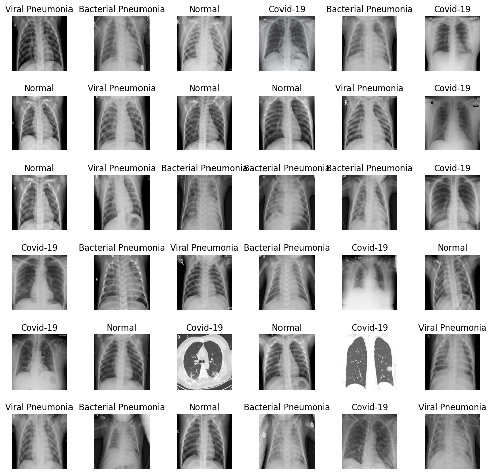

```python
#Visualization of the train_image data
#We create a grid of subplots, where each subplot displays an image from the train_images dataset and shows the corresponding label from the train_labels_name
L = 6
W = 6
fig, axes = plt.subplots(L, W, figsize = (12, 12))
axes = axes.ravel()

for i in np.arange(0, L*W):
  axes[i].imshow(train_images[i])
  axes[i].set_title(train_labels_name[np.argmax(train_labels[i])])
  axes[i].axis('off')

  plt.subplots_adjust(wspace = 0.5)
```

# MODELLING

The goal of this project is to classify X-ray images into four different categories, potentially representing different pulmonary diseases.

These model will follow a typical CNN architecture for image classification tasks, with multiple convolutional and max-pooling layers for feature extraction, and a fully connected layer for classification.

The models will follow these sequence:

1. Initialization of a sequential model in Keras,specifying the input shape of the model, which in this case is (256, 256, 3). This indicates that the input images have a resolution of 256x256 pixels and 3 color channels (RGB).
2. Next, we define a convolutional layer (Conv2D) with 32 filters of certain sizes, followed by a max-pooling layer (MaxPooling2D) with a certain pool size. Note (The convolutional layer extracts features from the input image, and the max-pooling layer downsamples the feature maps, reducing their spatial dimensions while preserving the most important features)
3. The subsequent lines follow a similar pattern, with increasing numbers of filters in the convolutional layers (64, 128, 256, 512) and additional max-pooling layers.
4. The Flatten layer, which flattens the output of the last convolutional layer into a 1D vector,
5. fInally, the output of the flatten layer is then fed into a fully connected (Dense) layer with 4 output units and a softmax activation function.

After training on 10 diffrent algorithms, the following results was obtained:

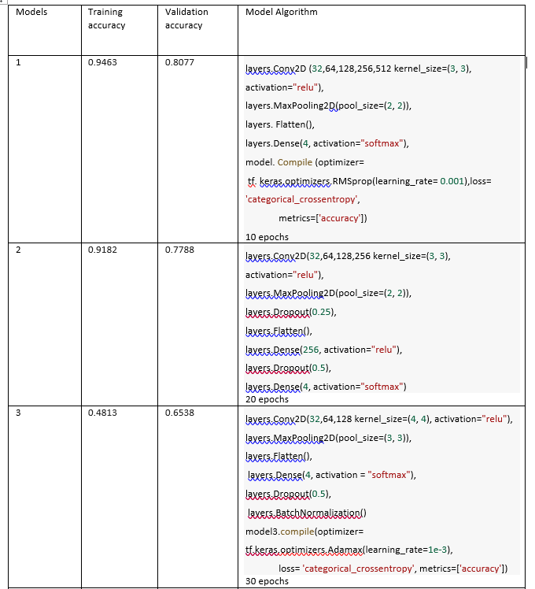

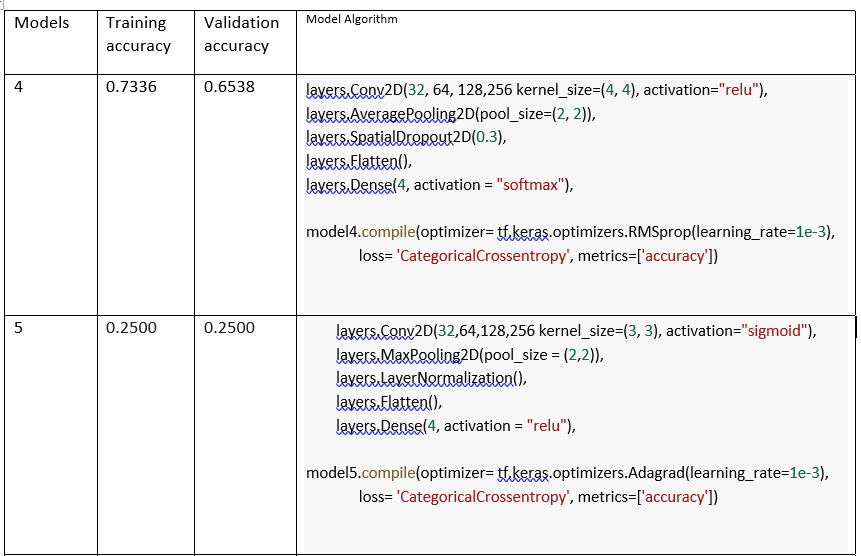

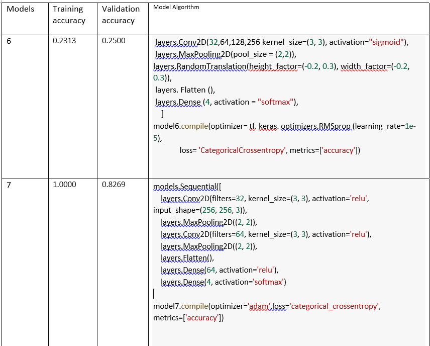

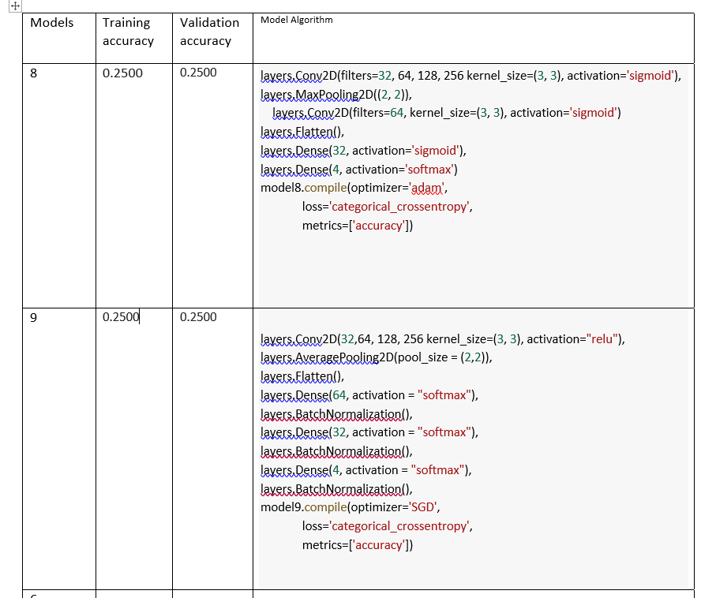

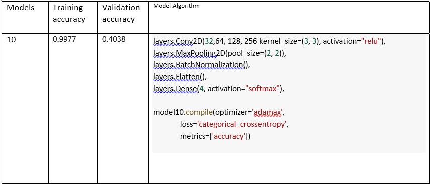

After evaluating 10 distinct Convolutional Neural Network models, Model 7 emerged as the optimal choice, achieving the highest validation accuracy of 0.8269 and a commendable training accuracy of 1.0000, striking an excellent balance between fitting the training data and generalizing to the validation set, outperforming the other 9 models in terms of validation performance within the specified number of training epochs.

```python
 from tensorflow.keras import datasets, layers, models
model = models.Sequential([
    layers.Conv2D(filters=32, kernel_size=(3, 3), activation='relu', input_shape=(256, 256, 3)),
    layers.MaxPooling2D((2, 2)),
    layers.Conv2D(filters=64, kernel_size=(3, 3), activation='relu'),
    layers.MaxPooling2D((2, 2)),
    layers.Flatten(),
    layers.Dense(64, activation='relu'),
    layers.Dense(4, activation='softmax'),
])
model.summary()
```

```
Model: "sequential_2"
_________________________________________________________________
 Layer (type)                Output Shape              Param #
=================================================================
 conv2d_4 (Conv2D)           (None, 254, 254, 32)      896

 max_pooling2d_4 (MaxPoolin  (None, 127, 127, 32)      0
 g2D)

 conv2d_5 (Conv2D)           (None, 125, 125, 64)      18496

 max_pooling2d_5 (MaxPoolin  (None, 62, 62, 64)        0
 g2D)

 flatten_2 (Flatten)         (None, 246016)            0

 dense_4 (Dense)             (None, 64)                15745088

 dense_5 (Dense)             (None, 4)                 260

=================================================================
Total params: 15764740 (60.14 MB)
Trainable params: 15764740 (60.14 MB)
Non-trainable params: 0 (0.00 Byte)
_________________________________________________________________
```

```python
model.compile(optimizer='adam',loss='categorical_crossentropy', metrics=['accuracy'])
```

```python
Test_model =  model.fit(test_generator, batch_size = 4, epochs = 10)
```

[output not shown]

Now, let's evaluate our model To evaluate our model:

1. Import the necessary library for evaluating the model's performance.
2. Initialize three empty lists:'predicted', 'Original', 'image'
3. Loop through the directory containing the test images organized into 4 subdirectories based on their class labels.
4. For each subdirectory represented by i, iterate through the image files inside that subdirectory.

```python
from sklearn.metrics import confusion_matrix, classification_report, accuracy_score

predicted = []
Original = []
image = []

for i in range (len(os.listdir('/kaggle/input/ds4work-operation-department/Test/'))):
  for item in os.listdir(os.path.join('/kaggle/input/ds4work-operation-department/Test/', str(i))):
    #read image fro directory using imread
    img = cv2.imread(os.path.join('/kaggle/input/ds4work-operation-department/Test/', str(i), item))
    #resize image read to 256x256 pixels
    img = cv2.resize(img,(256,256))
    #append the image to the image list
    image.append(img)
    #normalize pixel values
    img = img/255
    #Reshape image according to the expected input of the model
    img = img.reshape(-1, 256, 256,3)
    #Predict using the model
    predict = model.predict(img)
    #get the predicted class index by taking the argmax of the prediction probabilities
    predict = np.argmax(predict)
    #Append predicted class index to the predicted list
    predicted.append(predict)
    #Append the original class label to the Original list
    Original.append(i)
```

```python
score = accuracy_score(Original, predicted)
print("Test Accuracy: {}".format(score))
print(classification_report(np.asarray(Original), np.asarray(predicted)))
```

```
Test Accuracy: 0.975
              precision    recall  f1-score   support

           0       1.00      1.00      1.00        10
           1       1.00      1.00      1.00        10
           2       1.00      0.90      0.95        10
           3       0.91      1.00      0.95        10

    accuracy                           0.97        40
   macro avg       0.98      0.97      0.97        40
weighted avg       0.98      0.97      0.97        40
```

From the code above;

The model achieved an overall test accuracy of 0.975/97.5%.This means that the model correctly classified 97.5% of the X-ray images in the test dataset.

The model performed well across all 4 classes, with excellent precision and recall for Classes 0(100%, 100%) , 1 (100% and 100% ) and 2 (100%, 90%),

good to moderate performance for Class 3(91%, 100%).

The macro-averaged precision, recall, and F1-score, which give equal weight to all classes, are 0.98, 0.97, and 0.97, respectively, indicating good overall performance.

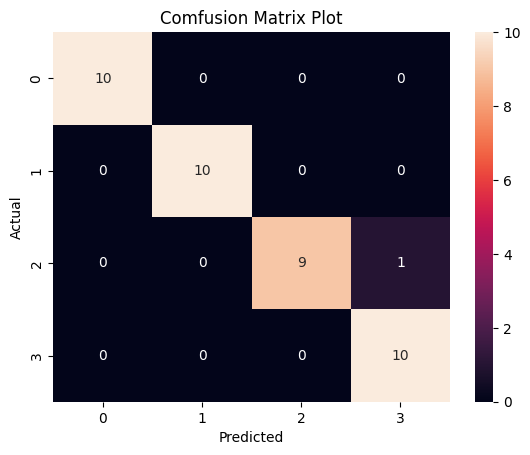

```python
CM = confusion_matrix(np.asarray(Original), np.asarray(predicted))
ax = plt.subplot()
sns.heatmap(CM, annot= True, ax = ax)
ax.set_xlabel('Predicted')
ax.set_ylabel('Actual')
ax.set_title('Comfusion Matrix Plot')
```

The Confusion Matrix plot consist of rows and columns, where the rows represents the actual image classes and the columns represents the predicted image classes

The diagonal elements represent the correctly classified instances of each class. In this case:

Class 0: 10 instances were correctly classified as Class 0.

Class 1: 10 instances were correctly classified as Class 1.

Class 2: 9 instances were correctly classified as Class 2.

Class 3: 10 instances were correctly classified as Class 3.

From the confusion matrix,

we observe that the model performed very well in classifying Classes 0 and 1, with no misclassifications.

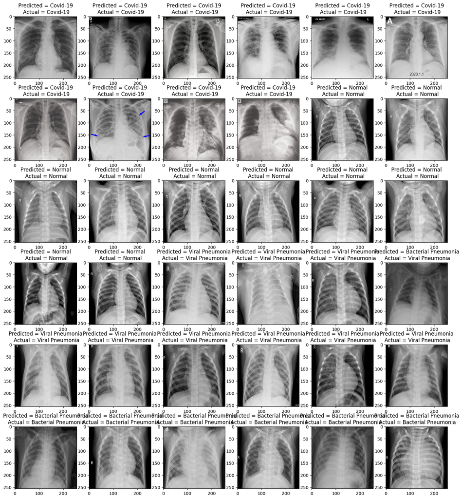

```python
#Finally, we visualize our predicted images with the actual images
L = 6
W = 6

fig, axes = plt.subplots(L, W, figsize = (18, 20))
axes = axes.ravel()

for i in np.arange(0, L*W):
  axes[i].imshow(image[i])
  axes[i].set_title("Predicted = {}\n Actual = {}". format(str(train_labels_name[predicted[i]]), str(train_labels_name[Original[i]])))
```

# CONCLUSION

The proposed solution to use Convolutional Neural Networks, for the automatic classification of pulmonary diseases based on X-ray images has shown promising results. The implemented CNN models were able to effectively learn hierarchical representations of the X-ray images by extracting simple features such as edges and shapes in the first layers and, based on these, detecting higher-level patterns and structures indicative of different pulmonary diseases.

One of the key strengths of the proposed solution is its ability to automate the process of disease classification, which can significantly reduce the time and labour required for manual analysis by radiologists.

The proposed solution can be integrated into existing healthcare systems, enabling real-time analysis of X-ray images and providing valuable insights to healthcare professionals, ultimately leading to better-informed treatment decisions and improved patient care.